# general thesis comments

Author

Ben Bolker

Published

April 16, 2026

When I send a marked-up version of a PDF, the notations are some mix of typographical, stylistic, etc. suggestions and notes to myself. Use what’s useful, ask me for clarification if you want, ignore anything else.

## graphics

- use larger text sizes in your figures (Wilke (2019) has an entire chapter titled “use larger axis labels”)
- consider colourblind-safe palettes (see Wilke (2019) §19.3)
- if possible use some kind of rasterization (e.g. convert PDFs to PNG) to reduce the size of large figures.
- if you’re using base-R graphics, consider using `par(las=1)` to make the y-axis tick labels horizontal (you may have to adjust the spacing/distance of the y-axis label from the y-axis)

## presentation of statistical results

- it’s almost never useful to show the absolute values of information-theoretic measures (AIC, BIC, etc.) or log-likelihoods; instead, show the differences from the best-fit model in a category (e.g. ΔAIC = AIC_i - min(AIC))
- strongly consider converting large tables of results to figures (Gelman 2011; Gelman, Pasarica, and Dodhia 2002) (note that one of these refs was published on April Fools’ day …) For example, this code, with this data file, converts this table:

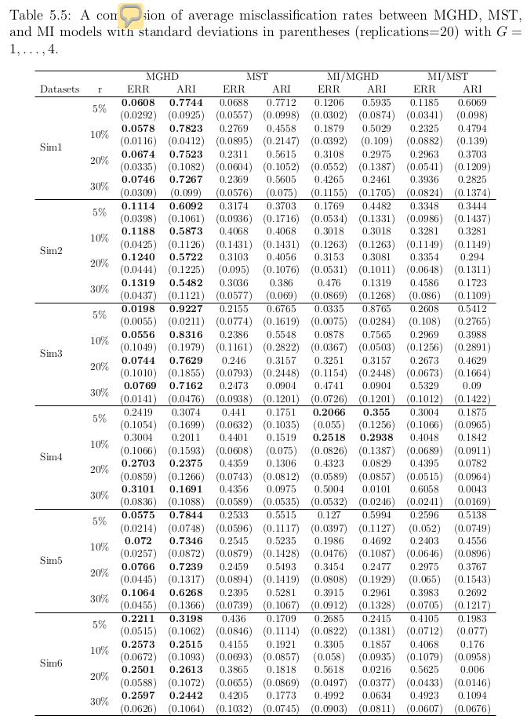

into this figure:

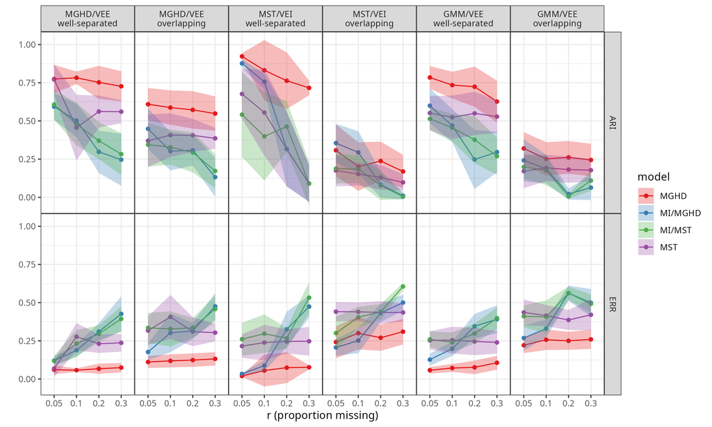

## References

- it’s OK to cite preprints if that is the only available form of a paper, but the published version is better if one exists

(see also reference stuff in [peeves](https://bbolker.github.io/bbmisc/peeves.html))

## BibTeX/LaTeX issues

### LaTeX

- check for open-quotes: LaTeX needs double-back-single-quotes rather than ” to start a double-quoted section
- check for missing references, either in your LaTeX log or by searching for ? in your document (typically you don’t use to many question marks in scholarly writing, so this should work OK)
- unless you intend to start a new paragraph, don’t follow a display equation with a blank line – LaTeX will think you want a new paragraph and indent the next line. For readability, you can include a line consisting only of a comment character `%`.

### BibTeX

- proper nouns and capitalized acronyms must be {}-protected in BibTeX code
- it’s nice to typeset species names in italics
- I prefer that journal titles be all-proper, i.e. *Journal of Chemical Physics* rather than *Journal of chemical physics*
- Published (conference/journal article) references are preferable to ArXiv references for the same document

## code archiving

- If you have code in your thesis, it should be open and fully reproducible (with some exceptions allowed for sensitive data, etc.).
- GitHub is not an archival site (Microsoft could shut it down or change the terms of service in the future): however, [Zenodo](https://zenodo.org/) is an archival site run by CERN that connects directly to GitHub. If you sign up for a Zenodo account, you can then link your GitHub account to it and archive the latest version of your code by clicking a single button. Zenodo will then provide a DOI which you should include in the text of your thesis. (Alternately, you can upload files directly to Zenodo.) If you have a different preferred archive site (e.g. OSF), you’re welcome to use that instead.

## language peeves

I have many preferences about language and style, see [here](https://bbolker.github.io/bbmisc/peeves.html) for a complete list.

In particular:

- “and” splices: “and” is often used to connect clauses that are only loosely connected: “Ducks are large and when they are approached by humans they make noise”. These passages can be stronger if they are split into separate sentences (“Ducks are large. When they are approached by humans they make noise.”) or separated with a semicolon (“Ducks are large; when they are approached by humans they make noise.”)
- avoid vague qualifiers: “quite”, “very”, “extremely”. Could you omit them without changing the meaning of your sentence? (also “significantly”, if not in a statistical context)
- I had it beaten into me in high school that “this” should never be used without an antecedent (“Ducks are bigger in the tropics. This means that …”) “This” what? Although I no longer believe it’s a hard-and-fast rule, include an antecedent whenever you can (“This enlargement means that …”); it will make your writing clearer.
- avoid “utili[sz]e” (use “use” instead)
- horn-blowing: “importantly”, “interestingly”. Your writing should be spare enough that you don’t need to emphasize particular results.
- Ditto for “Note that” and “Notably”.
- “unique”, “complex”, “dynamic”, “nonlinear”, “intricate”: are you using those words to denote something specific, or are you arm-waving about how cool and interesting your subject is?

## References

Gelman, Andrew. 2011. “Why Tables Are Really Much Better Than Graphs.” *Journal of Computational and Graphical Statistics* 20 (1): 3–7. https://doi.org/10.1198/jcgs.2011.09166.

Gelman, Andrew, Cristian Pasarica, and Rahul Dodhia. 2002. “Let’s Practice What We Preach: Turning Tables into Graphs.” *The American Statistician* 56 (2): 121–30.

Wilke, Claus O. 2019. *Fundamentals of Data Visualization: A Primer on Making Informative and Compelling Figures*. Sebastopol, CA: O’Reilly Media. https://clauswilke.com/dataviz/.